# DDSAnalytics

### Data Analysis - Attrition Visualization

Based on the visualization, we can see that Age, Business Travel, Distance from Home, Job Level, Monthly Income, Stock Option Level,Total Working Years, Years at Company, Years under Current Manager are important varibles that may predict Attrition. We will validate this numerically in the next section.

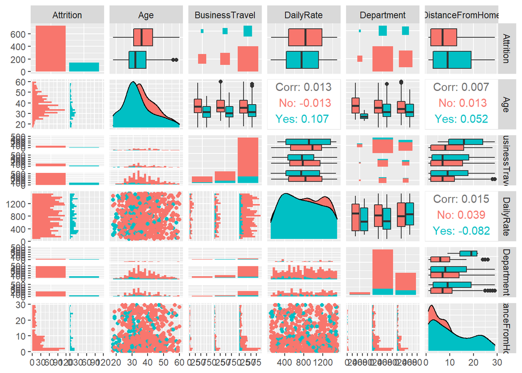

```r
library(dplyr)
library(ggplot2)
library(GGally)
#Visualizing data with attrition using 5 variables at a time
data %>%  select(Attrition,Age,BusinessTravel,DailyRate,Department,DistanceFromHome) %>% ggpairs(aes(color = Attrition))
```

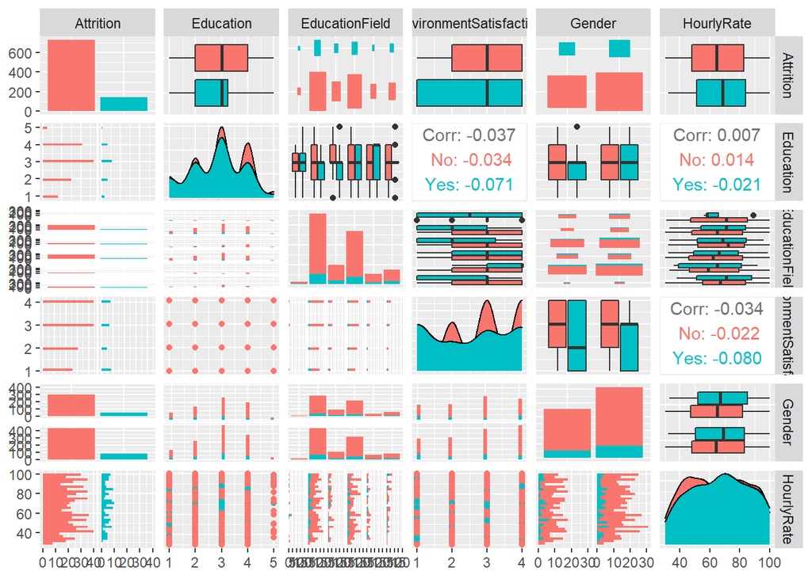

```r
data %>%  select(Attrition,Education,EducationField,EnvironmentSatisfaction,Gender,HourlyRate) %>% ggpairs(aes(color = Attrition))
```

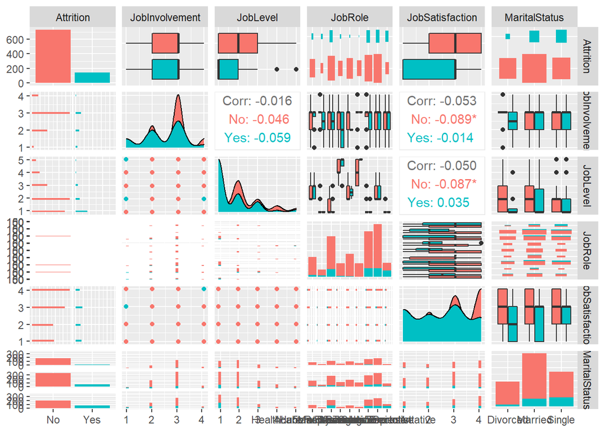

```r
data %>%  select(Attrition,JobInvolvement,JobLevel,JobRole,JobSatisfaction,MaritalStatus) %>% ggpairs(aes(color = Attrition))
```

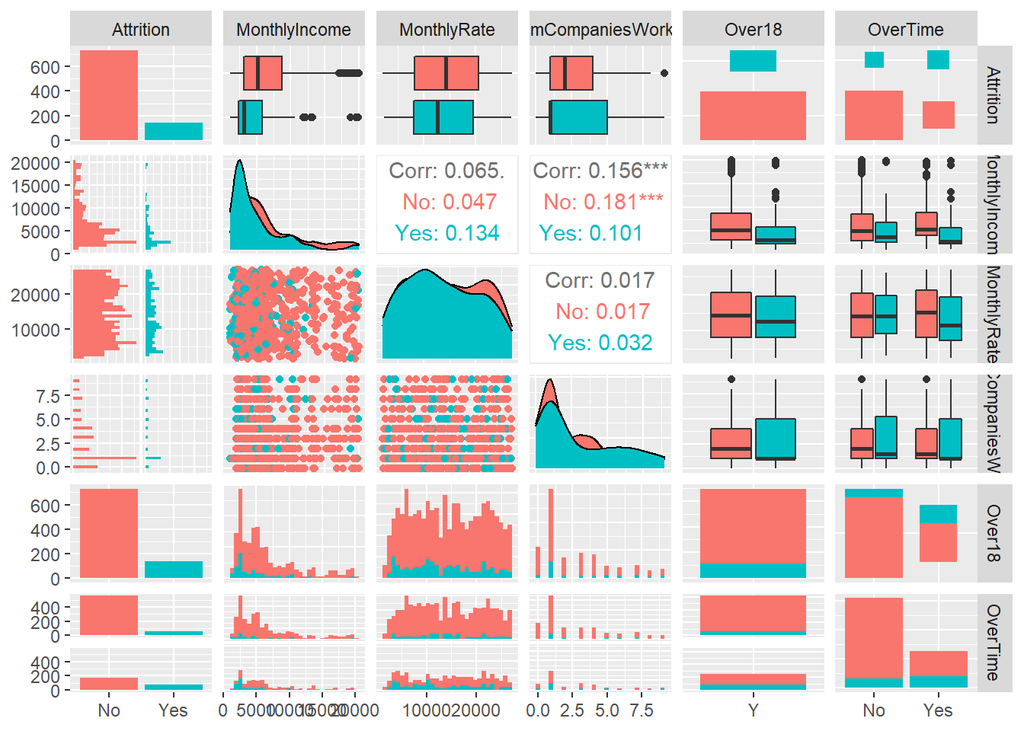

```r
data %>%  select(Attrition,MonthlyIncome,MonthlyRate,NumCompaniesWorked,Over18,OverTime) %>% ggpairs(aes(color = Attrition))
```

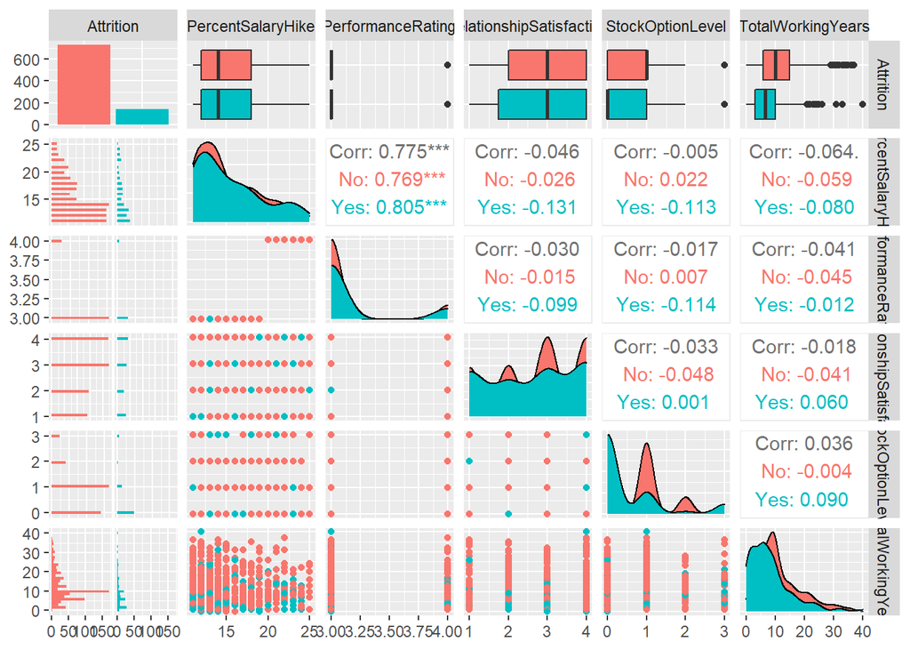

```r
data %>%  select(Attrition,PercentSalaryHike,PerformanceRating,RelationshipSatisfaction,StockOptionLevel,TotalWorkingYears) %>% ggpairs(aes(color = Attrition))
```

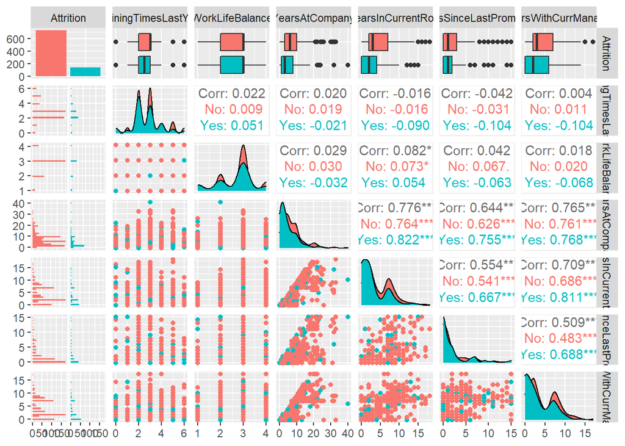

```r
data %>%  select(Attrition,TrainingTimesLastYear,WorkLifeBalance,YearsAtCompany,YearsInCurrentRole,YearsSinceLastPromotion,YearsWithCurrManager) %>% ggpairs(aes(color = Attrition))
```

## Attrition Analysis - Numeric

The same variables - Age, Distance from Home, Job Level, Monthly Income, Stock Option Level,Total Working Years, Years at Company, Years under Current Manager is highlighted numerically which validates our prediction in previous section.

```r
library(skimr)
newdata <- data %>% select(c(2,3:9,12:22,26:27,29:36))
dataatt <- newdata %>% group_by(Attrition)
skimr::skim(dataatt)
```

Data summary

| Name | dataatt |
| --- | --- |
| Number of rows | 870 |
| Number of columns | 29 |
| _______________________ |  |
| Column type frequency: |  |
| factor | 6 |
| numeric | 22 |
| ________________________ |  |
| Group variables | Attrition |

**Variable type: factor**

| skim_variable | Attrition | n_missing | complete_rate | ordered | n_unique | top_counts |
| --- | --- | --- | --- | --- | --- | --- |
| BusinessTravel | No | 0 | 1 | FALSE | 3 | Tra: 524, Tra: 123, Non: 83 |
| BusinessTravel | Yes | 0 | 1 | FALSE | 3 | Tra: 94, Tra: 35, Non: 11 |
| Department | No | 0 | 1 | FALSE | 3 | Res: 487, Sal: 214, Hum: 29 |
| Department | Yes | 0 | 1 | FALSE | 3 | Res: 75, Sal: 59, Hum: 6 |
| EducationField | No | 0 | 1 | FALSE | 6 | Lif: 305, Med: 233, Mar: 80, Tec: 58 |
| EducationField | Yes | 0 | 1 | FALSE | 6 | Lif: 53, Med: 37, Mar: 20, Tec: 17 |
| Gender | No | 0 | 1 | FALSE | 2 | Mal: 429, Fem: 301 |
| Gender | Yes | 0 | 1 | FALSE | 2 | Mal: 87, Fem: 53 |
| JobRole | No | 0 | 1 | FALSE | 9 | Sal: 167, Res: 140, Lab: 123, Man: 85 |
| JobRole | Yes | 0 | 1 | FALSE | 9 | Sal: 33, Res: 32, Lab: 30, Sal: 24 |
| MaritalStatus | No | 0 | 1 | FALSE | 3 | Mar: 352, Sin: 199, Div: 179 |
| MaritalStatus | Yes | 0 | 1 | FALSE | 3 | Sin: 70, Mar: 58, Div: 12 |

**Variable type: numeric**

| skim_variable | Attrition | n_missing | complete_rate | mean | sd | p0 | p25 | p50 | p75 | p100 | hist |
| --- | --- | --- | --- | --- | --- | --- | --- | --- | --- | --- | --- |
| Age | No | 0 | 1 | 37.41 | 8.67 | 18 | 31.00 | 36.0 | 43.00 | 60 | ▂▇▇▃▂ |
| Age | Yes | 0 | 1 | 33.79 | 9.61 | 18 | 28.00 | 32.0 | 39.00 | 58 | ▃▇▃▂▂ |
| DailyRate | No | 0 | 1 | 821.16 | 401.41 | 111 | 483.75 | 828.5 | 1178.25 | 1499 | ▇▇▇▇▇ |
| DailyRate | Yes | 0 | 1 | 784.29 | 399.56 | 103 | 428.75 | 751.0 | 1110.75 | 1496 | ▇▇▆▆▆ |
| DistanceFromHome | No | 0 | 1 | 9.03 | 7.98 | 1 | 2.00 | 7.0 | 13.00 | 29 | ▇▅▁▂▂ |
| DistanceFromHome | Yes | 0 | 1 | 10.96 | 8.75 | 1 | 3.00 | 9.0 | 19.00 | 29 | ▇▅▂▂▃ |
| Education | No | 0 | 1 | 2.92 | 1.02 | 1 | 2.00 | 3.0 | 4.00 | 5 | ▂▅▇▆▁ |
| Education | Yes | 0 | 1 | 2.79 | 1.01 | 1 | 2.00 | 3.0 | 3.25 | 5 | ▂▅▇▅▁ |
| EnvironmentSatisfaction | No | 0 | 1 | 2.74 | 1.08 | 1 | 2.00 | 3.0 | 4.00 | 4 | ▅▆▁▇▇ |
| EnvironmentSatisfaction | Yes | 0 | 1 | 2.51 | 1.19 | 1 | 1.00 | 3.0 | 4.00 | 4 | ▇▅▁▇▇ |
| HourlyRate | No | 0 | 1 | 65.29 | 20.20 | 30 | 48.00 | 64.5 | 82.75 | 100 | ▇▇▆▇▇ |
| HourlyRate | Yes | 0 | 1 | 67.29 | 19.71 | 32 | 51.00 | 68.5 | 84.00 | 100 | ▆▇▇▇▇ |
| JobInvolvement | No | 0 | 1 | 2.78 | 0.67 | 1 | 2.00 | 3.0 | 3.00 | 4 | ▁▃▁▇▁ |
| JobInvolvement | Yes | 0 | 1 | 2.42 | 0.81 | 1 | 2.00 | 3.0 | 3.00 | 4 | ▂▅▁▇▁ |
| JobLevel | No | 0 | 1 | 2.12 | 1.09 | 1 | 1.00 | 2.0 | 3.00 | 5 | ▇▇▃▂▁ |
| JobLevel | Yes | 0 | 1 | 1.64 | 0.98 | 1 | 1.00 | 1.0 | 2.00 | 5 | ▇▃▂▁▁ |
| JobSatisfaction | No | 0 | 1 | 2.76 | 1.11 | 1 | 2.00 | 3.0 | 4.00 | 4 | ▅▅▁▇▇ |
| JobSatisfaction | Yes | 0 | 1 | 2.44 | 1.09 | 1 | 1.00 | 3.0 | 3.00 | 4 | ▇▆▁▇▅ |
| MonthlyIncome | No | 0 | 1 | 6702.00 | 4675.47 | 1129 | 3162.00 | 5208.5 | 8736.50 | 19999 | ▇▅▂▁▂ |
| MonthlyIncome | Yes | 0 | 1 | 4764.79 | 3786.39 | 1081 | 2341.50 | 3171.0 | 5838.75 | 19859 | ▇▂▁▁▁ |
| MonthlyRate | No | 0 | 1 | 14460.12 | 7126.98 | 2094 | 8191.25 | 14235.5 | 20644.75 | 26997 | ▇▇▇▇▇ |
| MonthlyRate | Yes | 0 | 1 | 13624.29 | 6993.82 | 2396 | 8054.25 | 12651.0 | 19498.00 | 26959 | ▇▇▆▆▅ |
| NumCompaniesWorked | No | 0 | 1 | 2.66 | 2.47 | 0 | 1.00 | 2.0 | 4.00 | 9 | ▇▃▂▂▁ |
| NumCompaniesWorked | Yes | 0 | 1 | 3.08 | 2.77 | 0 | 1.00 | 1.0 | 5.00 | 9 | ▇▂▂▂▂ |
| PerformanceRating | No | 0 | 1 | 3.15 | 0.36 | 3 | 3.00 | 3.0 | 3.00 | 4 | ▇▁▁▁▂ |
| PerformanceRating | Yes | 0 | 1 | 3.16 | 0.37 | 3 | 3.00 | 3.0 | 3.00 | 4 | ▇▁▁▁▂ |
| RelationshipSatisfaction | No | 0 | 1 | 2.73 | 1.09 | 1 | 2.00 | 3.0 | 4.00 | 4 | ▅▅▁▇▇ |
| RelationshipSatisfaction | Yes | 0 | 1 | 2.61 | 1.16 | 1 | 1.75 | 3.0 | 4.00 | 4 | ▇▅▁▇▇ |
| StockOptionLevel | No | 0 | 1 | 0.84 | 0.84 | 0 | 0.00 | 1.0 | 1.00 | 3 | ▇▇▁▂▁ |
| StockOptionLevel | Yes | 0 | 1 | 0.49 | 0.90 | 0 | 0.00 | 0.0 | 1.00 | 3 | ▇▂▁▁▁ |
| TotalWorkingYears | No | 0 | 1 | 11.60 | 7.46 | 0 | 6.00 | 10.0 | 15.00 | 37 | ▆▇▃▁▁ |
| TotalWorkingYears | Yes | 0 | 1 | 8.19 | 7.16 | 0 | 3.00 | 6.5 | 10.00 | 40 | ▇▃▁▁▁ |
| TrainingTimesLastYear | No | 0 | 1 | 2.87 | 1.28 | 0 | 2.00 | 3.0 | 3.00 | 6 | ▂▇▇▂▃ |
| TrainingTimesLastYear | Yes | 0 | 1 | 2.65 | 1.23 | 0 | 2.00 | 2.5 | 3.00 | 6 | ▂▇▆▂▂ |
| WorkLifeBalance | No | 0 | 1 | 2.81 | 0.69 | 1 | 2.00 | 3.0 | 3.00 | 4 | ▁▃▁▇▂ |
| WorkLifeBalance | Yes | 0 | 1 | 2.64 | 0.82 | 1 | 2.00 | 3.0 | 3.00 | 4 | ▂▃▁▇▁ |
| YearsAtCompany | No | 0 | 1 | 7.30 | 5.94 | 0 | 3.00 | 6.0 | 10.00 | 33 | ▇▅▁▁▁ |
| YearsAtCompany | Yes | 0 | 1 | 5.19 | 6.17 | 0 | 1.00 | 3.0 | 8.00 | 40 | ▇▂▁▁▁ |
| YearsInCurrentRole | No | 0 | 1 | 4.45 | 3.64 | 0 | 2.00 | 3.0 | 7.00 | 18 | ▇▅▂▁▁ |
| YearsInCurrentRole | Yes | 0 | 1 | 2.91 | 3.33 | 0 | 0.00 | 2.0 | 4.00 | 15 | ▇▁▂▁▁ |
| YearsSinceLastPromotion | No | 0 | 1 | 2.18 | 3.15 | 0 | 0.00 | 1.0 | 3.00 | 15 | ▇▁▁▁▁ |
| YearsSinceLastPromotion | Yes | 0 | 1 | 2.14 | 3.40 | 0 | 0.00 | 1.0 | 2.00 | 15 | ▇▁▁▁▁ |
| YearsWithCurrManager | No | 0 | 1 | 4.37 | 3.59 | 0 | 2.00 | 3.0 | 7.00 | 17 | ▇▂▅▁▁ |
| YearsWithCurrManager | Yes | 0 | 1 | 2.94 | 3.24 | 0 | 0.00 | 2.0 | 6.00 | 14 | ▇▂▂▁▁ |

## Top 3 Attrition Reason

From the Attrition Analysis in previous 2 sections - Age, Business Travel,Distance from Home, Job Level, Monthly Income, Stock Option Level,Total Working Years, Years at Company were identified as important inputs for Attrition.I ran numerous models with knn and NB selecting the 3 variables at a time. The best model that I got was using Naive Bayes model with inputs Age, Business Travel , and Work Year(which was changed to Factor). The data was skewed heavily towards “No” attrition which meant that random sampling of total dataset didn’t yield enough “Yes” attrition. To tackle this issue, dataset was filtered into “Yes” and “No” attrition and ~80 % of “Yes” were samples every time along with ~75 % of “No”. 50 seeds were taken to get the mean for accuracy, sensitivity and Specificity.

```r
library(caret)
```

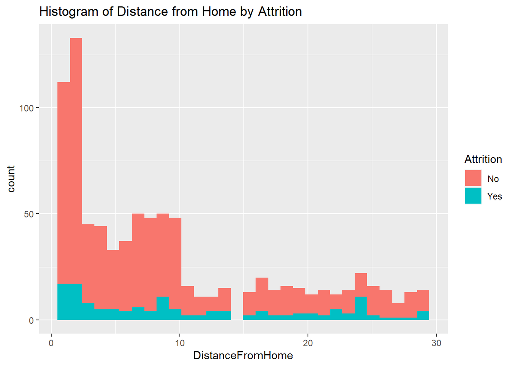

```r
library (e1071)
# Histograms for key inputs
datanb <- data
datanb %>% ggplot(aes(x= DistanceFromHome, fill=Attrition)) + geom_histogram() + ggtitle("Histogram of Distance from Home by Attrition")
```

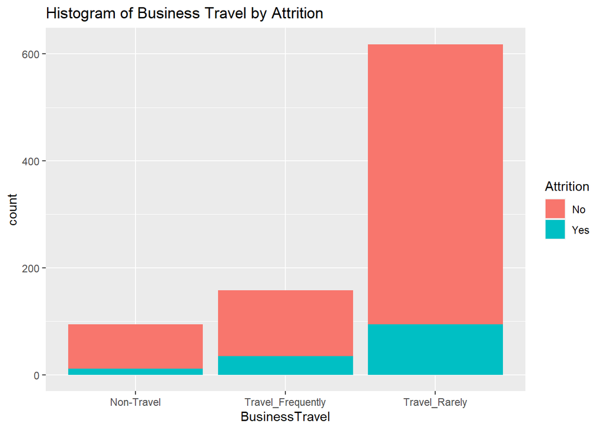

```r
datanb %>% ggplot(aes(x= BusinessTravel, fill=Attrition)) + geom_bar(stat="count") + ggtitle("Histogram of Business Travel by Attrition")
```

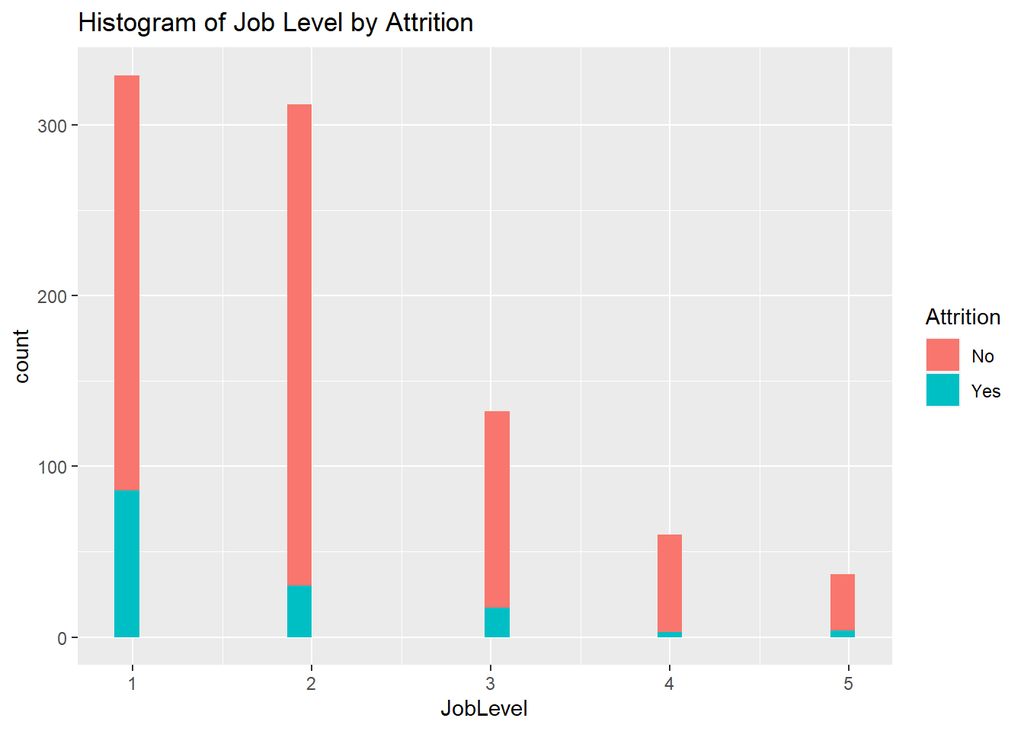

```r
datanb %>% ggplot(aes(x= JobLevel, fill=Attrition)) + geom_histogram() + ggtitle("Histogram of Job Level by Attrition")
```

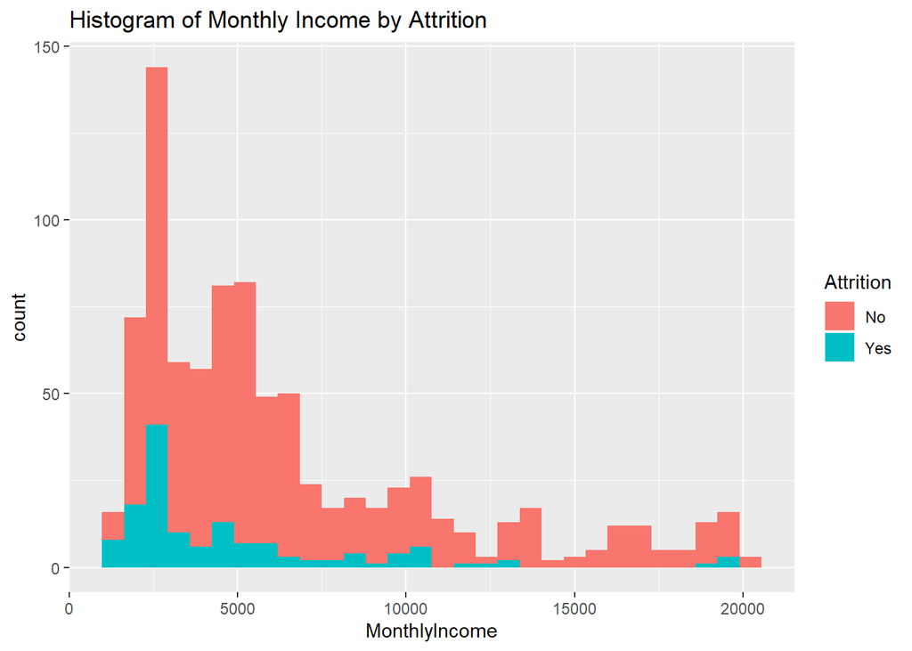

```r
datanb %>% ggplot(aes(x= MonthlyIncome, fill=Attrition)) + geom_histogram() + ggtitle("Histogram of Monthly Income by Attrition")
```

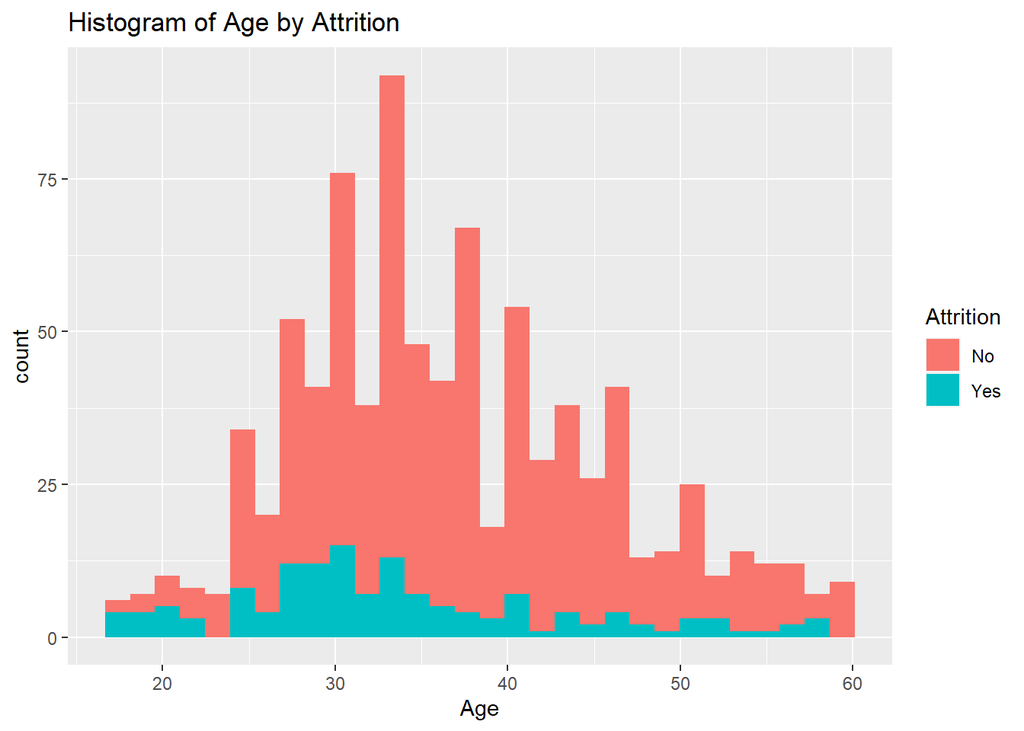

```r
datanb %>% ggplot(aes(x= Age, fill=Attrition)) + geom_histogram() + ggtitle("Histogram of Age by Attrition")
```

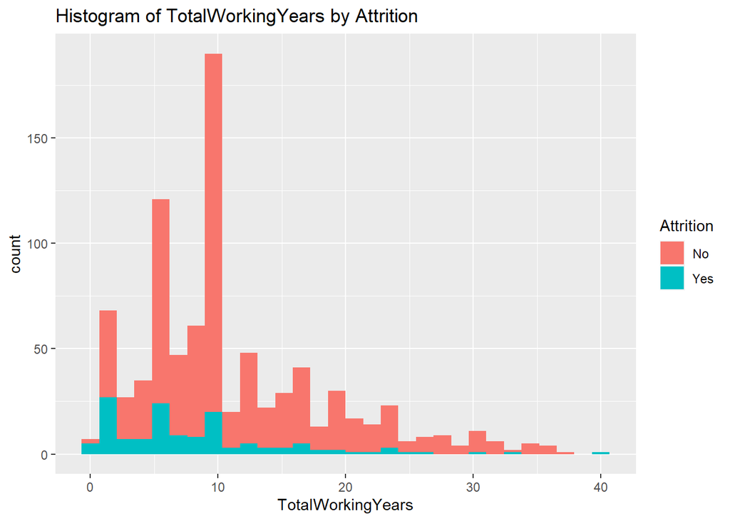

```r
datanb %>% ggplot(aes(x= TotalWorkingYears , fill=Attrition)) + geom_histogram() + ggtitle("Histogram of TotalWorkingYears by Attrition")
```

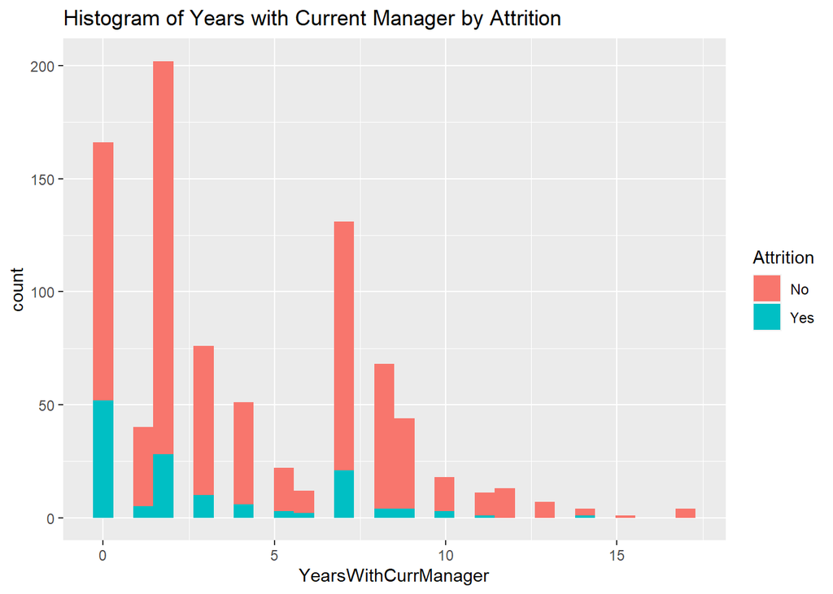

```r
datanb %>% ggplot(aes(x= YearsWithCurrManager  , fill=Attrition)) + geom_histogram() + ggtitle("Histogram of Years with Current Manager by Attrition")
```

```r
# Changing Work years to Factor with Levels based on Histogram
datanb$WorkYearFactor = cut(datanb$TotalWorkingYears, breaks = c(-1,11,21,40),labels = c("1","2","3"))

# Changing Age to Factor with Levels based on Histogram
datanb$AgeFactor = cut(datanb$Age, breaks = c(17,25,30,35,40,45,61),labels = c("1", "2", "3", "4", "5","6"))

# Changing Monthly Income to Factor with Levels based on Histogram
datanb$SalaryFactor = cut(datanb$MonthlyIncome, breaks = c(1080,3000,6000,12000,25000),labels = c("<3k","3k to 6k","6k to 12k",">12k"))

# Changing Years with Current Manager to Factor with Levels based on Histogram
datanb$YearsWithCurrManagerFactor  = cut(datanb$YearsWithCurrManager, breaks = c(-1,5,10,17),labels = c("Low","Med","High"))

# Creating dataset with "Yes" and "No" Attrition
datayes <- datanb %>% filter(Attrition =="Yes")
datano <- datanb %>% filter(Attrition =="No")

summary(datanb)
```

```
##        ID             Age        Attrition           BusinessTravel
##  Min.   :  1.0   Min.   :18.00   No :730   Non-Travel       : 94
##  1st Qu.:218.2   1st Qu.:30.00   Yes:140   Travel_Frequently:158
##  Median :435.5   Median :35.00             Travel_Rarely    :618
##  Mean   :435.5   Mean   :36.83
##  3rd Qu.:652.8   3rd Qu.:43.00
##  Max.   :870.0   Max.   :60.00
##
##    DailyRate                       Department  DistanceFromHome   Education
##  Min.   : 103.0   Human Resources       : 35   Min.   : 1.000   Min.   :1.000
##  1st Qu.: 472.5   Research & Development:562   1st Qu.: 2.000   1st Qu.:2.000
##  Median : 817.5   Sales                 :273   Median : 7.000   Median :3.000
##  Mean   : 815.2                                Mean   : 9.339   Mean   :2.901
##  3rd Qu.:1165.8                                3rd Qu.:14.000   3rd Qu.:4.000
##  Max.   :1499.0                                Max.   :29.000   Max.   :5.000
##
##           EducationField EmployeeCount EmployeeNumber   EnvironmentSatisfaction
##  Human Resources : 15    Min.   :1     Min.   :   1.0   Min.   :1.000
##  Life Sciences   :358    1st Qu.:1     1st Qu.: 477.2   1st Qu.:2.000
##  Marketing       :100    Median :1     Median :1039.0   Median :3.000
##  Medical         :270    Mean   :1     Mean   :1029.8   Mean   :2.701
##  Other           : 52    3rd Qu.:1     3rd Qu.:1561.5   3rd Qu.:4.000
##  Technical Degree: 75    Max.   :1     Max.   :2064.0   Max.   :4.000
##
##     Gender      HourlyRate     JobInvolvement     JobLevel
##  Female:354   Min.   : 30.00   Min.   :1.000   Min.   :1.000
##  Male  :516   1st Qu.: 48.00   1st Qu.:2.000   1st Qu.:1.000
##               Median : 66.00   Median :3.000   Median :2.000
##               Mean   : 65.61   Mean   :2.723   Mean   :2.039
##               3rd Qu.: 83.00   3rd Qu.:3.000   3rd Qu.:3.000
##               Max.   :100.00   Max.   :4.000   Max.   :5.000
##
##                       JobRole    JobSatisfaction  MaritalStatus MonthlyIncome
##  Sales Executive          :200   Min.   :1.000   Divorced:191   Min.   : 1081
##  Research Scientist       :172   1st Qu.:2.000   Married :410   1st Qu.: 2840
##  Laboratory Technician    :153   Median :3.000   Single  :269   Median : 4946
##  Manufacturing Director   : 87   Mean   :2.709                  Mean   : 6390
##  Healthcare Representative: 76   3rd Qu.:4.000                  3rd Qu.: 8182
##  Sales Representative     : 53   Max.   :4.000                  Max.   :19999
##  (Other)                  :129
```

[output cut: 25 more lines]

```
##  Min.   : 0.000     Min.   : 0.000          Min.   : 0.00        1:576
##  1st Qu.: 2.000     1st Qu.: 0.000          1st Qu.: 2.00        2:200
##  Median : 3.000     Median : 1.000          Median : 3.00        3: 94
##  Mean   : 4.205     Mean   : 2.169          Mean   : 4.14
##  3rd Qu.: 7.000     3rd Qu.: 3.000          3rd Qu.: 7.00
##  Max.   :18.000     Max.   :15.000          Max.   :17.00
##
##  AgeFactor    SalaryFactor YearsWithCurrManagerFactor
##  1: 72     <3k      :242   Low :557
##  2:150     3k to 6k :302   Med :273
##  3:217     6k to 12k:215   High: 40
##  4:156     >12k     :111
##  5:118
##  6:157
##
```

```r
# NaiveBayes Model with Age(2),Business Travel(4) and Work Year Factor (37)
AccHolder = numeric(50)
SensHolder = numeric(50)
SpecHolder = numeric(50)

for (seed in 1:50)
{
set.seed(seed)
trainIndices_yes = sample(seq(1:140),115)
trainIndices_no = sample(seq(1:730),555)
trainAttrition = rbind(datayes[trainIndices_yes,] , datano[trainIndices_no,])
testAttrition = rbind(datayes[-trainIndices_yes,], datano[-trainIndices_no,])
model = naiveBayes(trainAttrition[,c(2,4,37)],trainAttrition$Attrition)
CM = confusionMatrix(table(testAttrition$Attrition, predict(model,testAttrition[,c(2,4,37)])))
AccHolder[seed] = CM$overall[1]
SensHolder[seed] = CM$byClass[1]
SpecHolder[seed] = CM$byClass[2]
}

mean(AccHolder) # Mean Accuracy = 0.88
```

```
## [1] 0.8761
```

```r
#Standard Error of the Mean
sd(AccHolder)/sqrt(50)
```

```
## [1] 0.0002958902
```

```r
mean(SensHolder) # Mean Sensitivity = 0.88
```

```
## [1] 0.8759673
```

```r
#Standard Error of the Mean
sd(SensHolder)/sqrt(50)
```

```
## [1] 0.000260205
```

```r
mean(SpecHolder,na.rm = TRUE) # Mean Specificity = 1
```

```
## [1] 1
```

```r
#Standard Error of the Mean
sd(SensHolder)/sqrt(50)
```

```
## [1] 0.000260205
```

### Best Model to Predict Attrition

I realize that due to skewness, we need a model with high enough accuracy, sensitivity, but not too high specificity. I used Naive Bayes and knn models. The best values that I got was using Naive Bayes. I used 80% for Traning set and 20 % for test set. Due to skewness, the sets were bound from seperate Attrition and No Attrition datasets. The factors selected for my models are Age, Business Travel, Monthly Income, Work Years in factor and Years with Current Manager in Factor.

```r
# NaiveBayes Model with Age(2),Business Travel(4),Monthly Income (20),Work Year Factor (37), and Years with Current Manager Factor (40) to check if the model is stable.
AccHolder = numeric(50)
SensHolder = numeric(50)
SpecHolder = numeric(50)

for (seed in 1:50)
{
set.seed(seed)
trainIndices_yes = sample(seq(1:140),112)
trainIndices_no = sample(seq(1:730),584)
trainAttrition = rbind(datayes[trainIndices_yes,] , datano[trainIndices_no,])
testAttrition = rbind(datayes[-trainIndices_yes,], datano[-trainIndices_no,])
model = naiveBayes(trainAttrition[,c(2,4,20,40,37)],trainAttrition$Attrition)
CM = confusionMatrix(table(testAttrition$Attrition, predict(model,testAttrition[,c(2,4,20,40,37)])))
AccHolder[seed] = CM$overall[1]
SensHolder[seed] = CM$byClass[1]
SpecHolder[seed] = CM$byClass[2]
}

mean(AccHolder) # Mean Accuracy
```

```
## [1] 0.8462069
```

```r
mean(SensHolder) # Mean Sensitivity
```

```
## [1] 0.8494159
```

```r
mean(SpecHolder,na.rm = TRUE) # Mean Specificity
```

```
## [1] 0.7765306
```

```r
AccHolder
```

```
##  [1] 0.8333333 0.8563218 0.8390805 0.8620690 0.8275862 0.8448276 0.8448276
##  [8] 0.8563218 0.8505747 0.8505747 0.8505747 0.8448276 0.8390805 0.8448276
## [15] 0.8333333 0.8563218 0.8563218 0.8563218 0.8390805 0.8448276 0.8563218
## [22] 0.8448276 0.8505747 0.8505747 0.8505747 0.7931034 0.8275862 0.8563218
## [29] 0.8333333 0.8448276 0.8390805 0.8563218 0.8390805 0.8390805 0.8563218
## [36] 0.8448276 0.8505747 0.8563218 0.8505747 0.8448276 0.8505747 0.8505747
## [43] 0.8505747 0.8448276 0.8448276 0.8620690 0.8448276 0.8505747 0.8390805
## [50] 0.8563218
```

```r
SensHolder
```

```
##  [1] 0.8461538 0.8538012 0.8430233 0.8588235 0.8452381 0.8562874 0.8439306
##  [8] 0.8579882 0.8571429 0.8488372 0.8571429 0.8479532 0.8390805 0.8439306
## [15] 0.8502994 0.8538012 0.8538012 0.8579882 0.8470588 0.8439306 0.8538012
## [22] 0.8479532 0.8529412 0.8488372 0.8488372 0.8313253 0.8536585 0.8538012
## [29] 0.8421053 0.8439306 0.8430233 0.8579882 0.8430233 0.8470588 0.8538012
## [36] 0.8479532 0.8488372 0.8538012 0.8488372 0.8520710 0.8529412 0.8529412
## [43] 0.8488372 0.8439306 0.8439306 0.8588235 0.8439306 0.8488372 0.8430233
## [50] 0.8538012
```

```r
SpecHolder
```

```
##  [1] 0.4000000 1.0000000 0.5000000 1.0000000 0.3333333 0.5714286 1.0000000
##  [8] 0.8000000 0.6666667 1.0000000 0.6666667 0.6666667        NA 1.0000000
## [15] 0.4285714 1.0000000 1.0000000 0.8000000 0.5000000 1.0000000 1.0000000
## [22] 0.6666667 0.7500000 1.0000000 1.0000000 0.0000000 0.4000000 1.0000000
## [29] 0.3333333 1.0000000 0.5000000 0.8000000 0.5000000 0.5000000 1.0000000
## [36] 0.6666667 1.0000000 1.0000000 1.0000000 0.6000000 0.7500000 0.7500000
## [43] 1.0000000 1.0000000 1.0000000 1.0000000 1.0000000 1.0000000 0.5000000
## [50] 1.0000000
```

```r
# The mean values prove that the model is stable.

# The best seed that gave me a model high for accuracy and specifity and not too high for specifity is seed(9)
# Using seed 9 for the best model.
# Best prediction model
set.seed(9)
trainIndices_yes = sample(seq(1:140),112)
trainIndices_no = sample(seq(1:730),584)
trainAttrition = rbind(datayes[trainIndices_yes,] , datano[trainIndices_no,])
testAttrition = rbind(datayes[-trainIndices_yes,], datano[-trainIndices_no,])
model = naiveBayes(trainAttrition[,c(2,4,20,40,37)],trainAttrition$Attrition)
CM = confusionMatrix(table(testAttrition$Attrition, predict(model,testAttrition[,c(2,4,20,40,37)])))
model
```

```
##
## Naive Bayes Classifier for Discrete Predictors
##
## Call:
## naiveBayes.default(x = trainAttrition[, c(2, 4, 20, 40, 37)],
##     y = trainAttrition$Attrition)
##
## A-priori probabilities:
## trainAttrition$Attrition
##        No       Yes
## 0.8390805 0.1609195
##
## Conditional probabilities:
##                         Age
## trainAttrition$Attrition     [,1]     [,2]
##                      No  37.52397 8.570729
##                      Yes 33.43750 9.032256
##
##                         BusinessTravel
## trainAttrition$Attrition Non-Travel Travel_Frequently Travel_Rarely
##                      No  0.10787671        0.17123288    0.72089041
##                      Yes 0.05357143        0.25000000    0.69642857
##
##                         MonthlyIncome
## trainAttrition$Attrition     [,1]     [,2]
##                      No  6804.099 4761.912
##                      Yes 4838.009 3906.460
##
##                         YearsWithCurrManagerFactor
## trainAttrition$Attrition        Low        Med       High
##                      No  0.60787671 0.33732877 0.05479452
##                      Yes 0.72321429 0.25892857 0.01785714
##
##                         WorkYearFactor
## trainAttrition$Attrition          1          2          3
##                      No  0.61643836 0.25856164 0.12500000
##                      Yes 0.77678571 0.15178571 0.07142857
```

```r
CM
```

```
## Confusion Matrix and Statistics
##
##
##        No Yes
##   No  144   2
##   Yes  24   4
##
##                Accuracy : 0.8506
##                  95% CI : (0.7888, 0.9)
##     No Information Rate : 0.9655
##     P-Value [Acc > NIR] : 1
##
##                   Kappa : 0.1892
##
##  Mcnemar's Test P-Value : 3.814e-05
##
##             Sensitivity : 0.8571
##             Specificity : 0.6667
##          Pos Pred Value : 0.9863
##          Neg Pred Value : 0.1429
##              Prevalence : 0.9655
##          Detection Rate : 0.8276
##    Detection Prevalence : 0.8391
##       Balanced Accuracy : 0.7619
##
##        'Positive' Class : No
##
```

```r
# Accuracy = 0.8506
# Sensitivity = 0.8571
# Specificity = 0.6667

# Data modification for No Attrition Dataset

head(Casestudy2NoA)
```

```
##     ID Age    BusinessTravel DailyRate             Department DistanceFromHome
## 1 1171  35     Travel_Rarely       750 Research & Development               28
## 2 1172  33     Travel_Rarely       147        Human Resources                2
## 3 1173  26     Travel_Rarely      1330 Research & Development               21
## 4 1174  55     Travel_Rarely      1311 Research & Development                2
## 5 1175  29     Travel_Rarely      1246                  Sales               19
## 6 1176  51 Travel_Frequently      1456 Research & Development                1
##   Education  EducationField EmployeeCount EmployeeNumber
## 1         3   Life Sciences             1           1596
## 2         3 Human Resources             1           1207
## 3         3         Medical             1           1107
## 4         3   Life Sciences             1            505
## 5         3   Life Sciences             1           1497
## 6         4         Medical             1            145
##   EnvironmentSatisfaction Gender HourlyRate JobInvolvement JobLevel
```

[output cut: 41 more lines]

```r
Casestudy2NoA$SalaryFactor = cut(Casestudy2NoA$MonthlyIncome, breaks = c(1080,3000,6000,12000,25000),labels = c("<3k","3k to 6k","6k to 12k",">12k"))
Casestudy2NoA$BusinessTravel = as.factor(Casestudy2NoA$BusinessTravel)
Casestudy2NoA$JobLevelFactor = as.factor(Casestudy2NoA$JobLevel)
Casestudy2NoA$WorkYearFactor = cut(Casestudy2NoA$TotalWorkingYears, breaks = c(-1,11,21,40),labels = c("1","2","3"))
Casestudy2NoA$YearsWithCurrManagerFactor  = cut(Casestudy2NoA$YearsWithCurrManager, breaks = c(-1,5,10,17),labels = c("Low","Med","High"))



#Prediction of Attrition for No Attrition Data

Casestudy2NoA$NBPrediction = predict(model,Casestudy2NoA[,c(2,3,19,38,39)])

# Viewing the Prediction

Casestudy2NoA$NBPrediction
```

```
##   [1] No  No  No  No  No  No  No  No  No  No  No  No  No  No  No  No  No  No
##  [19] No  No  No  No  No  Yes No  No  No  No  No  No  No  No  No  No  Yes No
##  [37] No  No  No  No  No  No  No  No  No  No  No  No  No  Yes No  No  No  No
##  [55] No  No  No  No  No  No  No  No  Yes No  No  No  No  No  Yes No  No  No
##  [73] No  No  No  No  No  No  No  No  No  No  No  No  No  No  No  No  No  No
##  [91] No  No  No  No  No  No  No  No  No  No  No  No  No  No  No  No  No  No
## [109] No  No  No  No  No  No  No  No  No  No  No  No  No  No  No  No  No  No
## [127] No  No  No  No  No  No  No  No  No  No  No  No  No  No  No  No  No  No
## [145] No  No  No  No  No  No  No  No  No  No  No  No  No  No  Yes No  No  No
## [163] No  No  No  No  No  No  No  No  No  No  No  No  No  No  No  No  No  No
## [181] No  No  No  No  No  No  No  Yes No  No  No  No  No  No  No  No  No  No
## [199] No  No  No  No  No  No  No  No  No  No  No  No  Yes No  No  No  No  No
## [217] No  No  No  No  No  No  No  No  No  No  No  No  No  No  No  No  No  No
## [235] No  No  No  No  No  No  No  No  No  No  No  No  No  No  No  No  No  No
## [253] No  No  No  No  No  No  No  No  No  No  No  No  No  No  No  No  No  No
## [271] No  No  No  No  Yes No  No  No  No  No  No  No  No  No  No  No  No  No
## [289] No  No  No  No  No  No  No  No  No  No  No  No
## Levels: No Yes
```

```r
#writing csv file for submission
#write.csv(Casestudy2NoA,file = 'C:\\Users\\bhand\\OneDrive\\Desktop\\Doing Data Science\\Case Study 2/Case2PredictionsBhandariAttrition.csv')
```